# Homework 1

Ben Ridenhour

9/2/2021

## Part One, SIS Model

### Writing the System Down and Fixed Points

In the homework, you were asked to write down a simple difference to explain the change in an $S \rightarrow I \rightarrow S$ system, with parameters $\beta$ and $\gamma$. You were also told that infection rate was proportional $\beta \frac{I}{N}$. This yields the system:

$$\Delta S = -\beta S \frac{I}{N} + \gamma I \\
\Delta I = \beta S \frac{I}{N} - \gamma I.$$

We can simplify the system by realizing that $N = S + I$ and substituting. Doing so for the $\Delta S$ equation yields:

$$\Delta S =(N-S)(\gamma -\beta\frac{S}{N}).$$
Solving for the fixed points, $\hat{S}$, where $\Delta S = 0$, we get either $\hat{S} = N$ or $\frac{\hat{S}}{N} = \frac{\gamma}{\beta}$. Because $\frac{S}{N}\in[0,1]$ and $\gamma > 0$, we know that $\beta > \gamma$ is needed for valid solutions.

### Plotting the Solutions

I will borrow a slightly modified version of the `recur` function that can accept a vector of values. This will come in handy for the SIRS system in the next part. Here is the function with an example of passing it either a vector or a single value:

```r
recur <- function(f,f0,k,verbose=F,values = F){
  ret <- as.list(rep(NA,k+1))
  ret[[1]] <- f0
  for(i in 2:(k+1)) ret[[i]] <- f(ret[[i-1]])
  if(verbose) print(ret)
  if(values){
    if(length(f0) > 1) return(unname(t(as.matrix(data.frame(ret))))) else return(unlist(ret))
  }
  ret[[k+1]]
}

myfun <- function(x) c(x[1] * 2, x[2] * 3)

recur(myfun, c(1,3), 4, val=T)
```

```
##      [,1] [,2]
## [1,]    1    3
## [2,]    2    9
## [3,]    4   27
## [4,]    8   81
## [5,]   16  243
```

```r
myfun <- function(x) x^2

recur(myfun, 2, 4, val=T)
```

```
## [1]     2     4    16   256 65536
```

Now we need the function to do the recursion:

```r
deltaS  <- function(S, N, beta, gamma) S + (N-S)*(gamma - beta * S/N)
```

Finally, we will loop over value of $N, \beta,$ and $\gamma$ and plot them using `ggplot`. This borrows heavily from the code we went through last lecture.

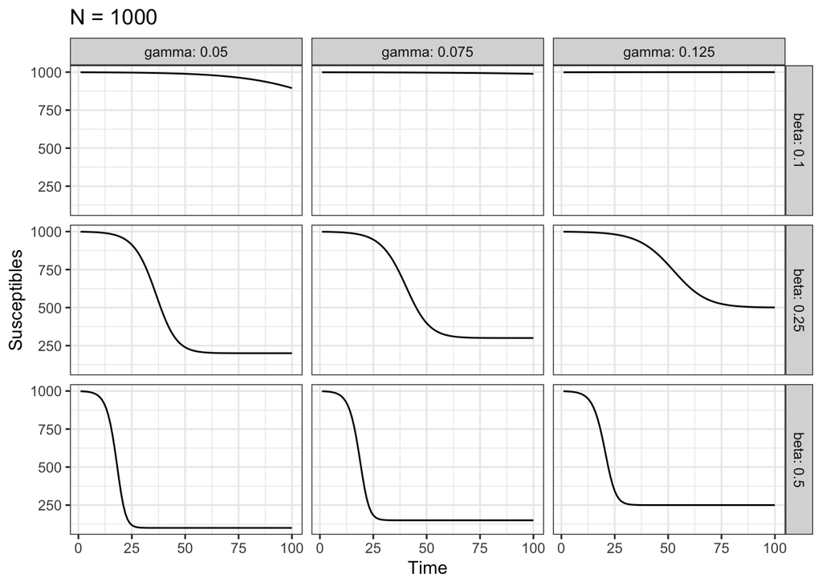

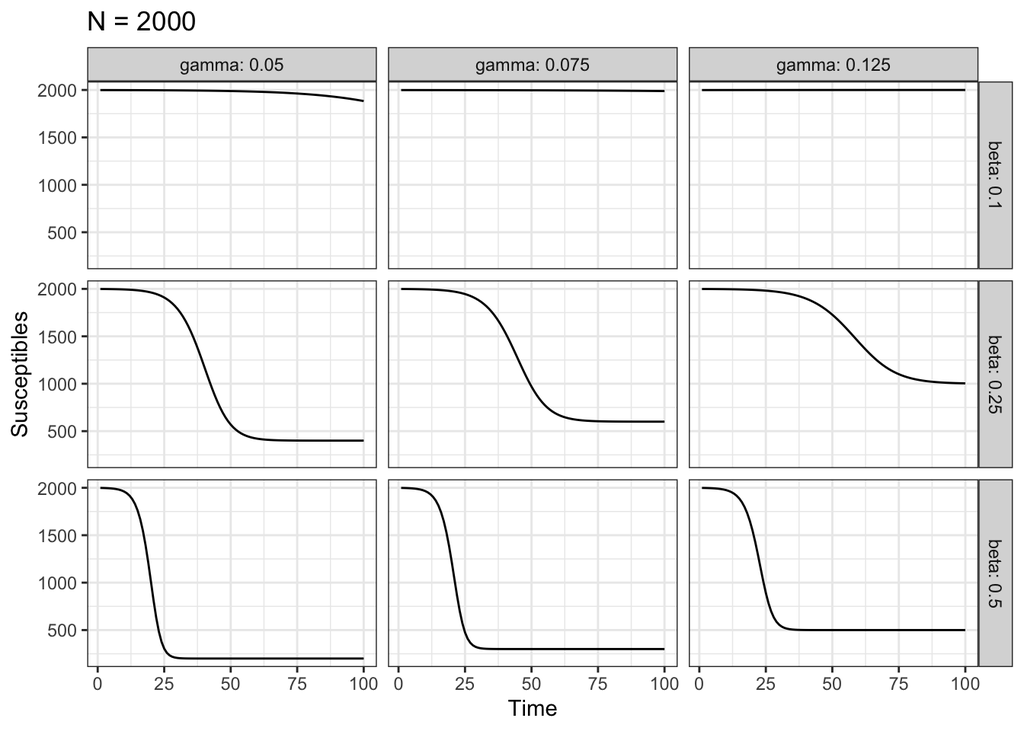

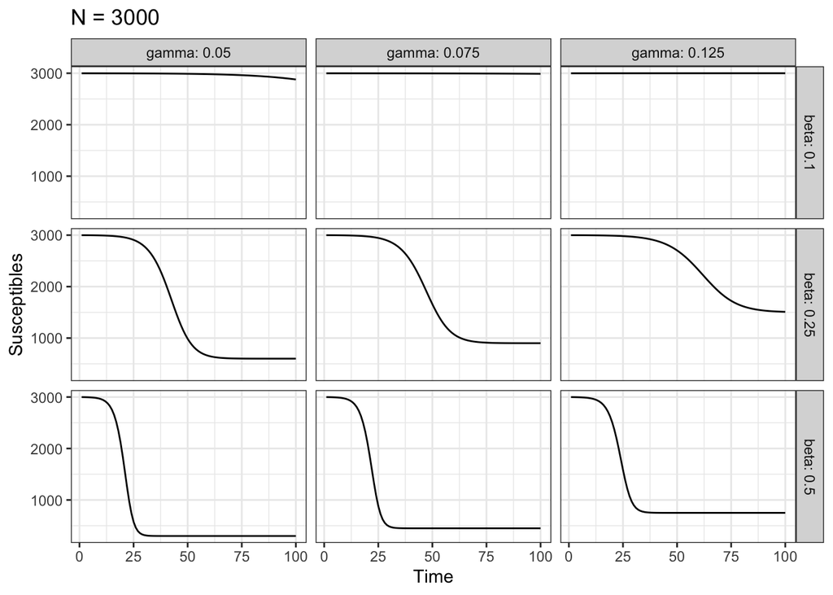

```r
N <- c(1000,2000,3000)
betas <- c(0.1,0.25,0.5)
gammas <- c(0.05, 0.075, 0.125)

library(ggplot2)

allData <- data.frame(N = 0, beta = 0, gamma = 0, Time = 0, S = 0)
allData <- allData[0,]

for(popn in N){
  popData <- data.frame(beta = 0, gamma = 0, Time = 0, S = 0)
  popData <- popData[0,]
  for(b in betas){
    for(g in gammas){
      popData <- rbind(popData,
                       data.frame(
                         beta = b,
                         gamma = g,
                         Time = 1:100,
                         S = recur(function(x) deltaS(x, popn, b, g), popn - 1, 100, val= T)[-1]
                       ))
    }
  }

  g <- ggplot(popData, aes(x=Time, y=S))
  g <- g + geom_line() + theme_bw() + ylab("Susceptibles") +
    ggtitle(paste("N =", popn, sep=" ")) + facet_grid(beta ~ gamma, labeller = labeller(.default = label_both))
  print(g)
  popData$N <- popn
  allData <- rbind(allData, popData)
}
```

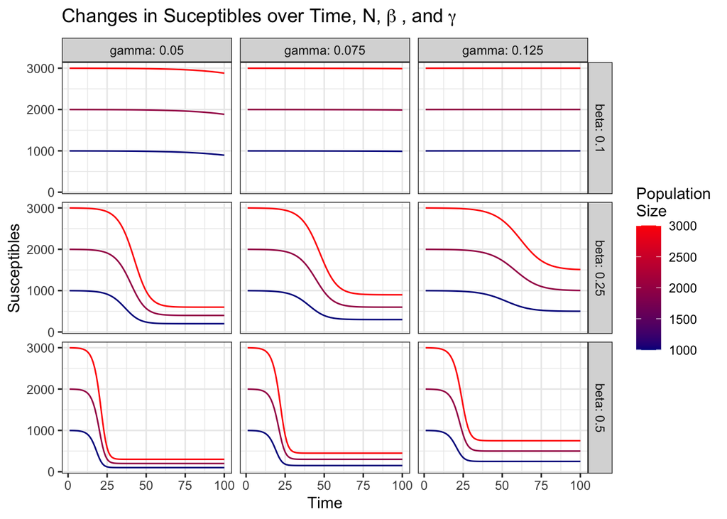

```r
g <- ggplot(allData, aes(x=Time, y=S, group = N, color = N))

g + geom_line() + theme_bw() + ylab("Susceptibles") +
  scale_color_gradient(name="Population\nSize", low="darkblue", high="red") +
  ggtitle(expression("Changes in Suceptibles over Time, N,"~beta~", and"~gamma)) +
  facet_grid(beta ~ gamma, labeller = labeller(.default = label_both))
```

## Part Two, SIRS Model

You were then asked to repeat the exercise but for a $S \rightarrow I \rightarrow R \rightarrow S$ model, where $\gamma$ now is used for the $I \rightarrow R$ transition and $\mu$ for the $R \rightarrow S$ transition. The system now becomes:

$$\Delta S = -\beta S \frac{I}{N} + \mu R \\
\Delta I = \beta S \frac{I}{N} - \gamma I \\
\Delta R = \gamma I - \mu R.$$

This system also can be simplified using $N = S + I + R$; doing so yields:

$$\Delta S = -\beta S \frac{I}{N} + \mu (N - S - I) \\
\Delta I = \beta S \frac{I}{N} - \gamma I.$$

Fixed points can once again be solved for, such that $(\hat{S},\hat{I}) = (N,0)$ or $(\frac{\hat{S}}{N},\frac{\hat{I}}{N}) = (\frac{\gamma}{\beta},\frac{\mu}{\mu + \gamma}(1-\frac{\gamma}{\beta}))$ which produces similar conditions on the parameters as the SIS system.

## Plotting the SIRS

Here is the slightly modified code from above to produce plots for the SIRS system:

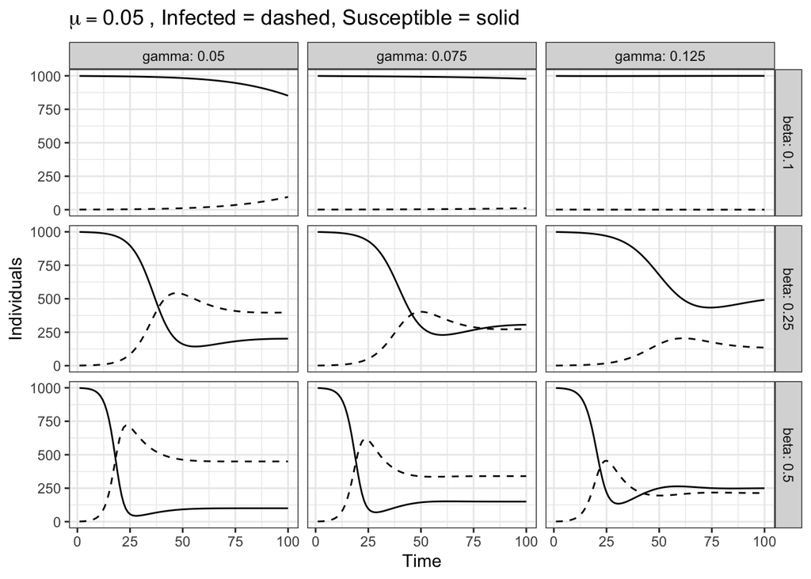

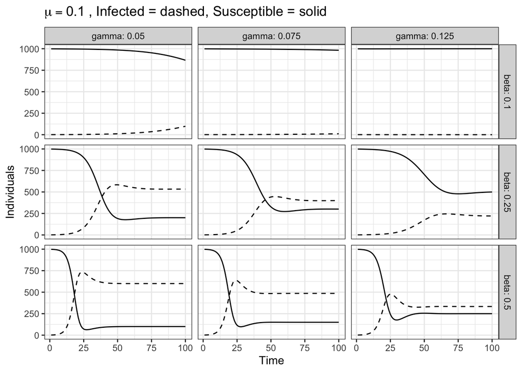

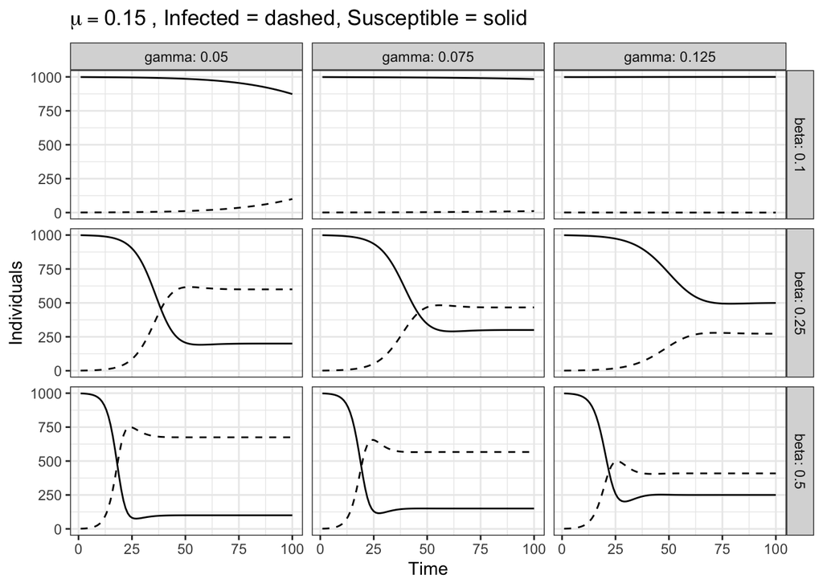

```r
#x should be a vector of length 2 with x[1] = S, x[2] = I
deltaSI <- function(x, N, beta, gamma, mu){
  S <- x[1]
  i <- x[2]
  newS <- S - beta * S * i/N + mu * (N - S - i)
  newI <- i + beta * S * i/N - gamma * i
  c(newS,newI)
}

allData <- data.frame(mu = 0, beta = 0, gamma = 0, Time = 0, S = 0, i = 0)
allData <- allData[0,]

mus <- c(0.05,0.1,0.15)

for(m in mus){
  popData <- data.frame(beta = 0, gamma = 0, Time = 0, S = 0, i = 0)
  popData <- popData[0,]
  for(b in betas){
    for(g in gammas){
      runData <- recur(function(x) deltaSI(x, 1000, b, g, m), c(999,1), 100, val= T)[-1,]
      popData <- rbind(popData,
                       data.frame(
                         beta = b,
                         gamma = g,
                         Time = 1:100,
                         S = runData[,1],
                         i = runData[,2]
                       ))
    }
  }

  g <- ggplot(popData, aes(x=Time, y=S))
  g <- g + geom_line() + geom_line(aes(y = i), lty = 2) + theme_bw() + ylab("Individuals") +
    ggtitle(bquote(mu == .(m)~", Infected = dashed, Susceptible = solid")) + facet_grid(beta ~ gamma, labeller = labeller(.default = label_both))
  print(g)
  popData$mu <- m
  allData <- rbind(allData, popData)
}
```

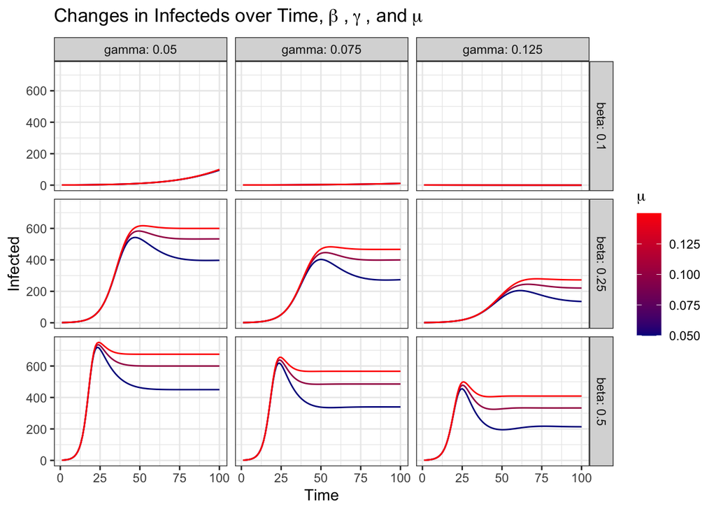

```r
g <- ggplot(allData, aes(x=Time, y=i, group = mu, color = mu))

g + geom_line() + theme_bw() + ylab("Infected") +
  scale_color_gradient(name=bquote(mu), low="darkblue", high="red") +
  ggtitle(bquote("Changes in Infecteds over Time,"~beta~","~gamma~", and"~mu)) +
  facet_grid(beta ~ gamma, labeller = labeller(.default = label_both))
```